# 02_Analysis

# Problem Solve

## SLA and LDMC correlation

Choosing to only include SLA and move LDMC to the supplemental so I want correlation information for the two traits.

```r
# 2021
# overall -usng the most dataframe. this does include one genotype for sla that is only in one treatment but the other option is to not include one genotype for ldmc. check with la dataframe to make sure no major differences.
cor.test(Dat_2021_most$SLA, Dat_2021_most$LDMC)
```

```
##
##  Pearson's product-moment correlation
##
## data:  Dat_2021_most$SLA and Dat_2021_most$LDMC
## t = -8.2934, df = 77, p-value = 2.767e-12
## alternative hypothesis: true correlation is not equal to 0
## 95 percent confidence interval:
##  -0.7882727 -0.5491800
## sample estimates:
##        cor
## -0.6868827
```

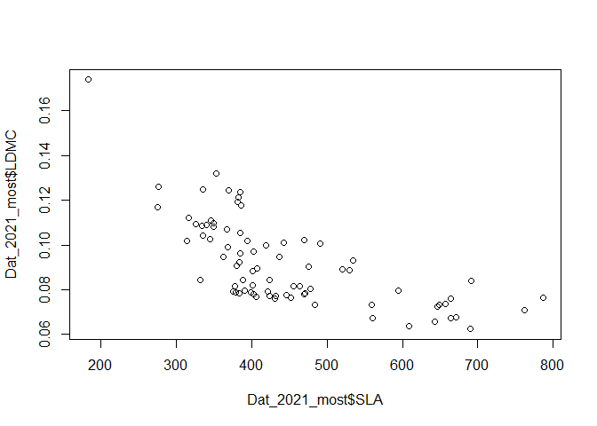

```r
plot(Dat_2021_most$SLA, Dat_2021_most$LDMC)
```

```r
cor.test(Dat_2021_la$SLA, Dat_2021_la$LDMC)
```

```
##
##  Pearson's product-moment correlation
##
## data:  Dat_2021_la$SLA and Dat_2021_la$LDMC
## t = -8.24, df = 76, p-value = 3.82e-12
## alternative hypothesis: true correlation is not equal to 0
## 95 percent confidence interval:
##  -0.7888568 -0.5481715
## sample estimates:
##        cor
## -0.6869095
```

```r
# slight difference but not meaningful interpretation wise -> round to same thing to the hundreths place

# just in SW
cor.test(Dat_2021_most[Dat_2021_most$Population == "RODA", ]$SLA, Dat_2021_most[Dat_2021_most$Population == "RODA", ]$LDMC)
```

```
##
##  Pearson's product-moment correlation
##
## data:  Dat_2021_most[Dat_2021_most$Population == "RODA", ]$SLA and Dat_2021_most[Dat_2021_most$Population == "RODA", ]$LDMC
## t = -8.5531, df = 48, p-value = 3.255e-11
## alternative hypothesis: true correlation is not equal to 0
## 95 percent confidence interval:
##  -0.8677229 -0.6363454
## sample estimates:
##        cor
## -0.7770567
```

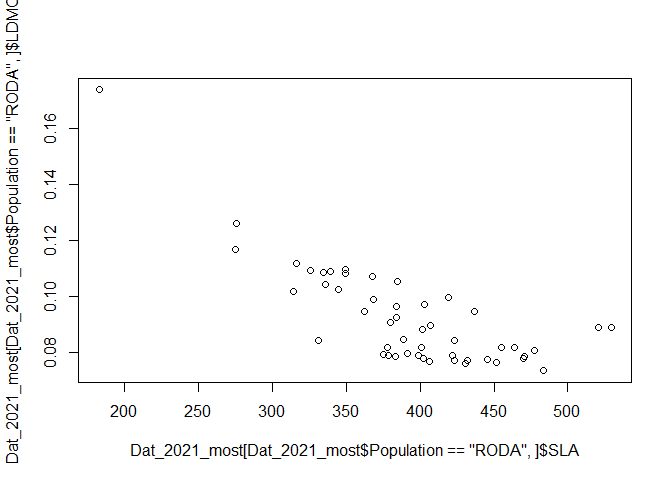

```r
plot(Dat_2021_most[Dat_2021_most$Population == "RODA", ]$SLA, Dat_2021_most[Dat_2021_most$Population == "RODA", ]$LDMC)
```

```r
# just in IT
cor.test(Dat_2021_la[Dat_2021_la$Population == "BELM", ]$SLA, Dat_2021_la[Dat_2021_la$Population == "BELM", ]$LDMC)
```

```
##
##  Pearson's product-moment correlation
##
## data:  Dat_2021_la[Dat_2021_la$Population == "BELM", ]$SLA and Dat_2021_la[Dat_2021_la$Population == "BELM", ]$LDMC
## t = -10.678, df = 26, p-value = 5.318e-11
## alternative hypothesis: true correlation is not equal to 0
## 95 percent confidence interval:
##  -0.9542183 -0.7979505
## sample estimates:
##       cor
## -0.902389
```

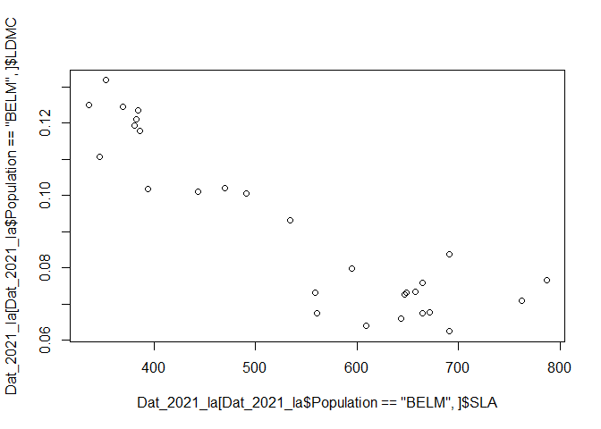

```r
plot(Dat_2021_la[Dat_2021_la$Population == "BELM", ]$SLA, Dat_2021_la[Dat_2021_la$Population == "BELM", ]$LDMC)
```

```r
# just cur?
cor.test(Dat_2021_la[Dat_2021_la$Treatment == "Current", ]$SLA, Dat_2021_la[Dat_2021_la$Treatment == "Current", ]$LDMC)
```

```
##
##  Pearson's product-moment correlation
##
## data:  Dat_2021_la[Dat_2021_la$Treatment == "Current", ]$SLA and Dat_2021_la[Dat_2021_la$Treatment == "Current", ]$LDMC
## t = -6.0587, df = 37, p-value = 5.229e-07
## alternative hypothesis: true correlation is not equal to 0
## 95 percent confidence interval:
##  -0.8352434 -0.5019506
## sample estimates:
##        cor
## -0.7057027
```

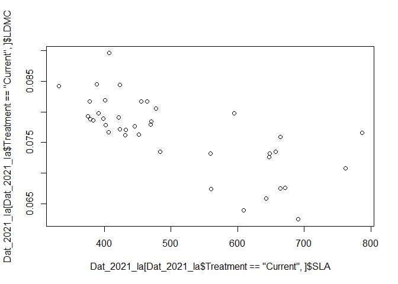

```r
plot(Dat_2021_la[Dat_2021_la$Treatment == "Current", ]$SLA, Dat_2021_la[Dat_2021_la$Treatment == "Current", ]$LDMC)
```

```r
# just fut?
cor.test(Dat_2021_la[Dat_2021_la$Treatment == "Future", ]$SLA, Dat_2021_la[Dat_2021_la$Treatment == "Future", ]$LDMC)
```

```
##
##  Pearson's product-moment correlation
##
## data:  Dat_2021_la[Dat_2021_la$Treatment == "Future", ]$SLA and Dat_2021_la[Dat_2021_la$Treatment == "Future", ]$LDMC
## t = -5.5666, df = 37, p-value = 2.426e-06
## alternative hypothesis: true correlation is not equal to 0
## 95 percent confidence interval:
##  -0.8166714 -0.4569261
## sample estimates:
##        cor
## -0.6751134
```

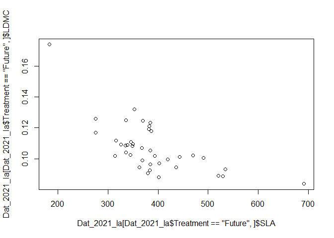

```r
plot(Dat_2021_la[Dat_2021_la$Treatment == "Future", ]$SLA, Dat_2021_la[Dat_2021_la$Treatment == "Future", ]$LDMC)
```

```r
# 2022
# overall
cor.test(Dat_2022c$SLA, Dat_2022c$LDMC)
```

```
##
##  Pearson's product-moment correlation
##
## data:  Dat_2022c$SLA and Dat_2022c$LDMC
## t = -12.462, df = 123, p-value < 2.2e-16
## alternative hypothesis: true correlation is not equal to 0
## 95 percent confidence interval:
##  -0.8156319 -0.6576910
## sample estimates:
##       cor
## -0.747021
```

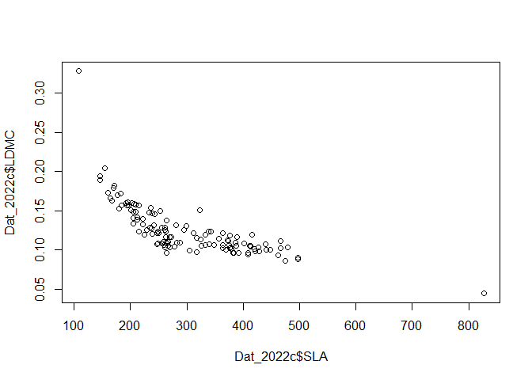

```r
plot(Dat_2022c$SLA, Dat_2022c$LDMC)
```

```r
# just in SW
cor.test(Dat_2022c[Dat_2022c$Population == "R", ]$SLA, Dat_2022c[Dat_2022c$Population == "R", ]$LDMC)
```

```
##
##  Pearson's product-moment correlation
##
## data:  Dat_2022c[Dat_2022c$Population == "R", ]$SLA and Dat_2022c[Dat_2022c$Population == "R", ]$LDMC
## t = -14.604, df = 60, p-value < 2.2e-16
## alternative hypothesis: true correlation is not equal to 0
## 95 percent confidence interval:
##  -0.9283496 -0.8130558
## sample estimates:
##        cor
## -0.8834225
```

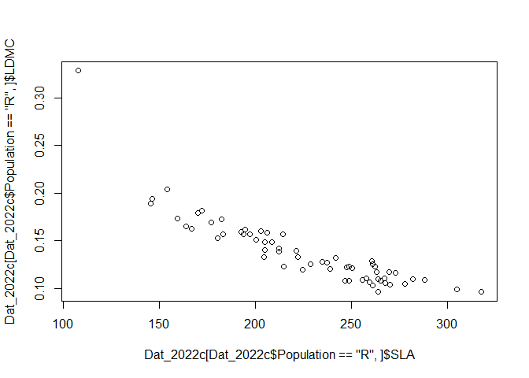

```r
plot(Dat_2022c[Dat_2022c$Population == "R", ]$SLA, Dat_2022c[Dat_2022c$Population == "R", ]$LDMC)
```

```r
# just in IT
cor.test(Dat_2022c[Dat_2022c$Population == "B", ]$SLA, Dat_2022c[Dat_2022c$Population == "B", ]$LDMC)
```

```
##
##  Pearson's product-moment correlation
##
## data:  Dat_2022c[Dat_2022c$Population == "B", ]$SLA and Dat_2022c[Dat_2022c$Population == "B", ]$LDMC
## t = -13.99, df = 61, p-value < 2.2e-16
## alternative hypothesis: true correlation is not equal to 0
## 95 percent confidence interval:
##  -0.9215464 -0.7980171
## sample estimates:
##        cor
## -0.8731435
```

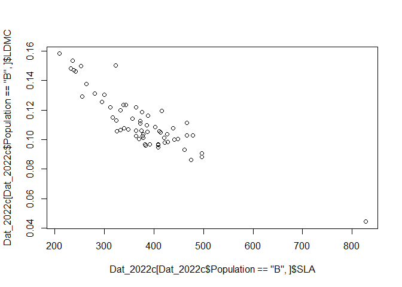

```r
plot(Dat_2022c[Dat_2022c$Population == "B", ]$SLA, Dat_2022c[Dat_2022c$Population == "B", ]$LDMC)
```

```r
# just cur?
cor.test(Dat_2022c[Dat_2022c$Treatment == "Current", ]$SLA, Dat_2022c[Dat_2022c$Treatment == "Current", ]$LDMC)
```

```
##
##  Pearson's product-moment correlation
##
## data:  Dat_2022c[Dat_2022c$Treatment == "Current", ]$SLA and Dat_2022c[Dat_2022c$Treatment == "Current", ]$LDMC
## t = -5.7691, df = 62, p-value = 2.724e-07
## alternative hypothesis: true correlation is not equal to 0
## 95 percent confidence interval:
##  -0.7306769 -0.4038851
## sample estimates:
##        cor
## -0.5910188
```

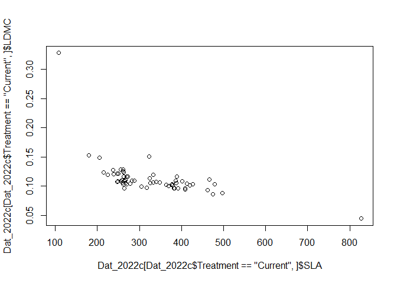

```r
plot(Dat_2022c[Dat_2022c$Treatment == "Current", ]$SLA, Dat_2022c[Dat_2022c$Treatment == "Current", ]$LDMC)
```

```r
# just fut?
cor.test(Dat_2022c[Dat_2022c$Treatment == "Future", ]$SLA, Dat_2022c[Dat_2022c$Treatment == "Future", ]$LDMC)
```

```
##
##  Pearson's product-moment correlation
##
## data:  Dat_2022c[Dat_2022c$Treatment == "Future", ]$SLA and Dat_2022c[Dat_2022c$Treatment == "Future", ]$LDMC
## t = -16.554, df = 59, p-value < 2.2e-16
## alternative hypothesis: true correlation is not equal to 0
## 95 percent confidence interval:
##  -0.9434207 -0.8492816
## sample estimates:
##        cor
## -0.9071031
```

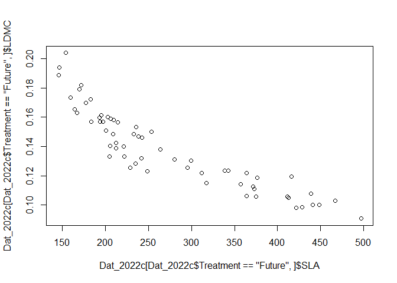

```r
plot(Dat_2022c[Dat_2022c$Treatment == "Future", ]$SLA, Dat_2022c[Dat_2022c$Treatment == "Future", ]$LDMC)
```

## Dry weight difference in signficance For dry weight, there is a huge difference in significance between 2021 (p value below 0.001) and 2022 (p value above 0.95). Quickly looking at the spreadsheets I can not tell a difference and the values are of similar magnitudes. I then did untransformed models and square root transformed models because those were reported as having the most normal residuals in the previous code. None of the models had differences in p values due to transformation that changed the interpretation of the results. I also excluded the “days between bolting and harvest” random effect for the 2022 data but did not find a major difference in the models but the denominator degrees of freedom for treatment did change a lot. As a final check for if there is a potential mistake, I am going to look at some data distributions.

```r
ggplot(dat = Dat_2021_most)+
  geom_histogram(aes(x = DriedWt_g, fill = Population), alpha = 0.5, position = "identity")+
  theme_classic()
ggplot(dat = Dat_2021_RosSeed)+
  geom_histogram(aes(x = DriedWt_g, fill = Treatment), alpha = 0.5, position = "identity")+
  theme_classic()


ggplot(dat = Dat_2022c)+
  geom_histogram(aes(x = SL_DryWt, fill = Population), alpha = 0.5, position = "identity")+
  theme_classic()
ggplot(dat = Dat_2022c)+
  geom_histogram(aes(x = SL_DryWt, fill = Treatment), alpha = 0.5, position = "identity")+
  theme_classic()
```

[output not shown]

## 2021 Avg Seed per fruit

Concerned that line does not explain any variance. Is it true that all the variation is within lines and not between lines? to check this: 1) make histogram of all the values (not line means) - done in CleanData but repeat here

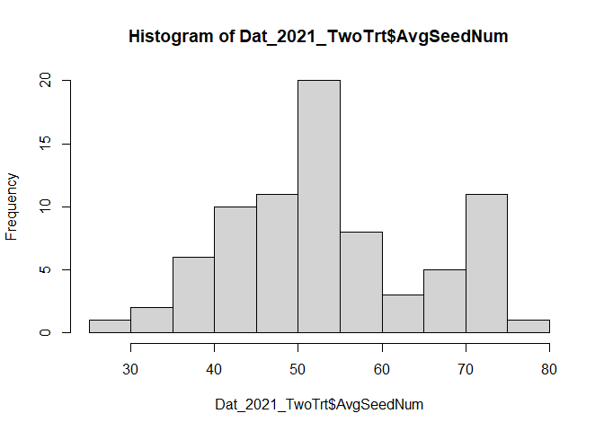

```r
hist(Dat_2021_TwoTrt$AvgSeedNum)
```

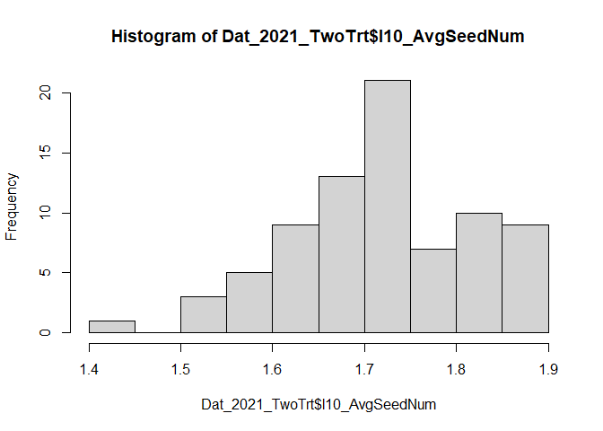

```r
hist(Dat_2021_TwoTrt$l10_AvgSeedNum)
```

2) look within lines for difference in avg seeds/fruit - maybe do subtraction and histogram the differences? but won’t work if more than two values

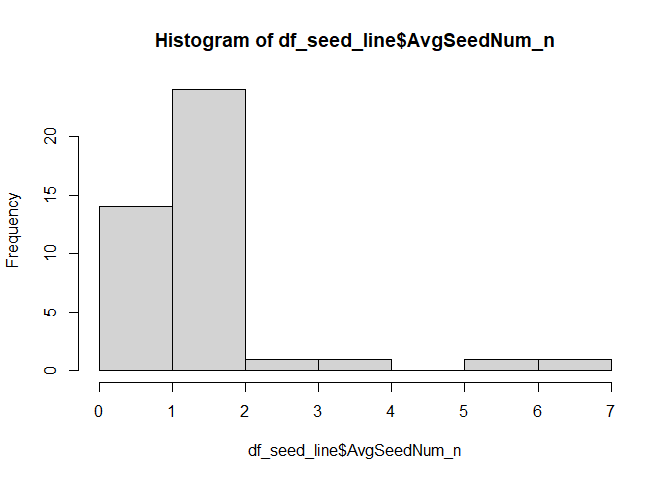

```r
# start with copy of code from 03_Figures that makes the by line plot
Dat_2021_TwoTrt$Line.ID <- as.factor(paste0(Dat_2021_TwoTrt$Population, Dat_2021_TwoTrt$Line))
Dat_2021_TwoTrt$Line.ID.T <- as.factor(paste0(Dat_2021_TwoTrt$Line.ID, Dat_2021_TwoTrt$Treatment))
df_seed_line <- Dat_2021_TwoTrt %>%
  dplyr::group_by(Line.ID.T, .add = TRUE) %>%
  summarize(across(.col = c(AvgSeedNum, l10_AvgSeedNum), .fns = list(mean = ~mean(.x, na.rm = TRUE, .group = "keep"), ci_95 = ~conf_int(.x), n = ~sum(!is.na(.)))))
df_seed_line$Population <- substr(df_seed_line$Line.ID.T, start = 1, stop = 4)

hist(df_seed_line$AvgSeedNum_n)
```

```r
# some lines only have 1 pot per treatment -- 10 instances, 7 in Cur
# some lines only have pots in one treatment 4 - all in Fut are the dead ones so only a rep in cur
# 3 and 4 are Roda parent. 6 and 7 are Belm parent.

# get list of Line.ID with 2 replicates
two_reps <- df_seed_line[df_seed_line$AvgSeedNum_n == 2, "Line.ID.T"]$Line.ID.T
# pull those out of the main dataframe
two_reps_seeds <- Dat_2021_TwoTrt[Dat_2021_TwoTrt$Line.ID.T %in% two_reps, c("Treatment", "Population", "Line", "Replicate", "Line.ID", "Line.ID.T", "AvgSeedNum", "l10_AvgSeedNum")]

# find the difference in values
two_reps_diff <-  two_reps_seeds %>%
  group_by(Line.ID.T) %>%
  summarize(across(.col = c(AvgSeedNum, l10_AvgSeedNum), .fns = ~diff(.x)))


# table of just RIL parent seed numbers
ril_pars_seed <- Dat_2021_TwoTrt[Dat_2021_TwoTrt$Line.ID %in% c("BELM12", "RODA47"), c("Treatment", "Population", "Line", "Replicate", "Line.ID", "Line.ID.T", "AvgSeedNum", "l10_AvgSeedNum")]
ril_pars_seed[order(ril_pars_seed$Line.ID.T), ]
```

```
##    Treatment Population Line Replicate Line.ID     Line.ID.T AvgSeedNum
## 1    Current       BELM   12        11  BELM12 BELM12Current   50.40000
## 3    Current       BELM   12        12  BELM12 BELM12Current   52.30000
## 5    Current       BELM   12        13  BELM12 BELM12Current   37.80000
## 7    Current       BELM   12        14  BELM12 BELM12Current   53.10000
## 9    Current       BELM   12        15  BELM12 BELM12Current   52.40000
## 13   Current       BELM   12         1  BELM12 BELM12Current   27.10000
## 15   Current       BELM   12         2  BELM12 BELM12Current   49.60000
## 2     Future       BELM   12        11  BELM12  BELM12Future   53.80000
## 4     Future       BELM   12        12  BELM12  BELM12Future   42.00000
## 6     Future       BELM   12        13  BELM12  BELM12Future   43.20000
## 8     Future       BELM   12        14  BELM12  BELM12Future   36.30000
## 10    Future       BELM   12        15  BELM12  BELM12Future   53.80000
## 14    Future       BELM   12         1  BELM12  BELM12Future         NA
## 16    Future       BELM   12         2  BELM12  BELM12Future   54.88889
```

[output cut: 39 more lines]

3. figure out which genotypes are the outliers on the residuals plot.The low outlier on the residuals plot is B12. Note for interpretation that the residuals are scaled (so not log scale but divided by the mean)

```r
tmp_seed <- lmer(l10_AvgSeedNum ~ Treatment * Population + (1|Population:Line) , data = Dat_2021_TwoTrt, contrasts = list(Treatment=contr.sum, Population = contr.sum))
```

```
## boundary (singular) fit: see help('isSingular')
```

```r
df_seed <- data.frame(fitted = fitted(tmp_seed),
                      resid = residuals(tmp_seed, type = "pearson", scaled = TRUE),
                      pop = Dat_2021_TwoTrt$Population[complete.cases(Dat_2021_TwoTrt$l10_AvgSeedNum)],
                      trt = Dat_2021_TwoTrt$Treatment[complete.cases(Dat_2021_TwoTrt$l10_AvgSeedNum)],
                      line = Dat_2021_TwoTrt$Line[complete.cases(Dat_2021_TwoTrt$l10_AvgSeedNum)],
                      pot.id = Dat_2021_TwoTrt$Pot.ID[complete.cases(Dat_2021_TwoTrt$l10_AvgSeedNum)])

plot_seed <-  ggplot(df_seed) +
  geom_point(aes(x=fitted, y=resid,
       col = pop, shape = trt, text=pot.id))+
  scale_color_manual(values = c("red", "blue"))+
  theme_classic()
ggplotly(plot_seed)
```

[interactive chart not shown]

make a plot with genotype on the x axis and seed count per fruit on the y axis. color by pop and treatment.

[interactive chart not shown]

# test selection gradient

```r
# create subset for each pop x trt combination (4 subsets) - only keeping traits related to avoidance/escape that are not too highly correlated and keeps the number of predictors decently low

# sweden - cur has 27 plants, fut has 25
sw_cur <- Dat_2021_TwoTrt[Dat_2021_TwoTrt$Population == "RODA" & Dat_2021_TwoTrt$Treatment == "Current", c("Pot.ID", "Population", "Line", "Replicate", "Treatment", "RWC", "SLA", "EmergeToFlwr", "fitness")]

sw_fut <- Dat_2021_TwoTrt[Dat_2021_TwoTrt$Population == "RODA" & Dat_2021_TwoTrt$Treatment == "Future", c("Pot.ID", "Population", "Line", "Replicate", "Treatment", "RWC", "SLA", "EmergeToFlwr", "fitness")]

# italy - cur has 18 plants, fut has 15 plants
it_cur <- Dat_2021_TwoTrt[Dat_2021_TwoTrt$Population == "BELM" & Dat_2021_TwoTrt$Treatment == "Current", c("Pot.ID", "Population", "Line", "Replicate", "Treatment", "RWC", "SLA", "EmergeToFlwr", "fitness")]

it_fut <- Dat_2021_TwoTrt[Dat_2021_TwoTrt$Population == "BELM" & Dat_2021_TwoTrt$Treatment == "Future", c("Pot.ID", "Population", "Line", "Replicate", "Treatment", "RWC", "SLA", "EmergeToFlwr", "fitness")]

# need to calculate relative fitness and scale the variables
sw_cur <- sw_cur %>%
  mutate(rel.fit = fitness / max(fitness, na.rm = T),
         RWC = c(scale(RWC, center = T, scale = T)),
         SLA = c(scale(SLA, center = T, scale = T)),
         EmergeToFlwr = c(scale(EmergeToFlwr, center = T, scale = T))
  )

sw_fut <- sw_fut %>%
  mutate(rel.fit = fitness / max(fitness, na.rm = T),
         RWC = c(scale(RWC, center = T, scale = T)),
         SLA = c(scale(SLA, center = T, scale = T)),
         EmergeToFlwr = c(scale(EmergeToFlwr, center = T, scale = T))
  )

it_cur <- it_cur %>%
  mutate(rel.fit = fitness / max(fitness, na.rm = T),
         RWC = c(scale(RWC, center = T, scale = T)),
         SLA = c(scale(SLA, center = T, scale = T)),
         EmergeToFlwr = c(scale(EmergeToFlwr, center = T, scale = T))
  )

it_fut <- it_fut %>%
  mutate(rel.fit = fitness / max(fitness, na.rm = T),
         RWC = c(scale(RWC, center = T, scale = T)),
         SLA = c(scale(SLA, center = T, scale = T)),
         EmergeToFlwr = c(scale(EmergeToFlwr, center = T, scale = T))
  )

# run the selection gradients
sg_sw_cur <- lmer(rel.fit ~ RWC + SLA + EmergeToFlwr + (1|Line), data = sw_cur)
summary(sg_sw_cur) # nothing significant

sg_sw_fut <- lmer(rel.fit ~ RWC + SLA + EmergeToFlwr + (1|Line), data = sw_fut)
summary(sg_sw_fut) # actually does show selection for earlier flowering

sg_it_cur <- lmer(rel.fit ~ RWC + SLA + EmergeToFlwr + (1|Line), data = it_cur)
summary(sg_it_cur) # nothing significant

sg_it_fut <- lmer(rel.fit ~ RWC + SLA + EmergeToFlwr + (1|Line), data = it_fut)
summary(sg_it_fut) # nothing significant
```

[output not shown]

End of code.